# Predicting shear modulus at small strain from CPTU data, using ensembled machine learning

Erdi Myftaraga

*HINTS: Click the `Hide Toolbars` button on the bottom-right for a better view and use the `Table of Content` on the top-left to navigate through the document.*

# 1 INTRODUCTION

The following is a short post on predicting small-strain stiffness properties from CPTU measurements by ensembling several machine learning (ML) models. More specifically, we are going to predict the value of the shear modulus at small strain, `Gmax`. The basic workflow can be summarized in these steps:

- read, explore and prepare the data;
- train several models using measurements of `Gmax` values derived from SCPT tests;
- combine the output of these models to generate an ensembled model;
- use the final ensembled model to generate `Gmax` values from all other CPTU measurements.

Here I will use open-source data from the HKN offshore wind farm in the Netherlands, which are provided from the [RVO WEBSITE](https://offshorewind.rvo.nl/) 👏👏👏

It is important to emphasize that this is mainly a demonstrative blog post, meaning that I am not doing very technically-strict analyses here. Although I am going to work on various aspects on geotechnical site assessment, those topics won’t be treated in detail, and often, simplified approaches or existing analyses will be used. I will try to be careful to emphasize the points where these “shortcuts” are adopted.

# 2 SETUP

The analysis is done using the R programming language. All the code is incorporated in the writing, so it’s clear which code chunk produces each piece of the output. Code parts are put in dark squares, to make it easy to separate them from the general text and the graphics. If you are not familiar with R, chances are that you can still follow along with the code, since the used syntax is relatively easy. For any questions/remarks you can also of course contact me [here](https://www.linkedin.com/in/erdi-myftaraga/).

## 2.1 Libraries

The first step is to load few packages that will make life easier for us, since they facilitate a lot of stuff. We don’t strictly need all these packages but few of them are used just for aesthetic purposes. I have also loaded some fonts from Google Fonts, mainly to make our plots and text look prettier.

```r
# libraries
library(tidyverse)
library(tidymodels)
library(stacks)
library(vroom)
library(readxl)
library(showtext)
library(slider)
library(bslib)
library(ggforce)
library(ggtext)
library(thematic)
library(kableExtra)
library(patchwork)
library(paletteer)

# fonts
font_add_google("Fira Code", "Fira Code")
showtext_auto()
```

Besides the code shown here, I’ll also make use of few source files and functions which include some relatively long code to read and format AGS 4.0 files, to create plotting themes, etc. I excluded those from this post since it’s already a long one.

## 2.2 Functions and helpers

Here, some functions and properties we are going to use through the analysis.

Colors to be used:

```r
# color preview functions
color_preview_dep <-
  function() {
  htmltools::htmlDependency(
    name = "color_preview",
    version = "0.0.1",
    src = ".",
    all_files = FALSE,
    head = "
<style>.color-preview {
  display: inline-block;
  width: 1em;
  height: 1em;
  border-radius: 50%;
  margin: 0 0.33em;
  vertical-align: middle;
  transition: transform 100ms ease-in-out;
}

.color-preview:hover {
  cursor: pointer;
  transform: scale(2);
  transform-origin: 50% 50%;
}</style>"
  )
}

color_preview <-
  function(color) {
  htmltools::tagList(
    htmltools::span(
      class = "color-preview",
      style = paste("background-color:", color),
      .noWS = "outside"
    ),
    htmltools::code(color, .noWS = "outside"),
    color_preview_dep()
  )
}
```

```r
# colors
col_r <- "#ef476f"
col_y <- "#ffd166"
col_g <- "#06d6a0"
col_b <- "#118ab2"

colors <- c(
  "#ef476f",
  "#ffd166",
  "#06d6a0",
  "#118ab2"
)

items_color <-
  lapply(colors, function(color) {
  htmltools::tags$li(color_preview(color))
})
htmltools::tags$ul(items_color)
```

- `#ef476f`
- `#ffd166`
- `#06d6a0`
- `#118ab2`

```r
# grays
gray_1 <- "#2F2F2FFF"
gray_2 <- "#474747FF"
gray_3 <- "#DFDFDFFF"
gray_4 <- "#F7F7F7FF"

grays <- c(
  "#2F2F2FFF",
  "#474747FF",
  "#DFDFDFFF",
  "#F7F7F7FF"
)

items_gray <-
  lapply(grays, function(color) {
  htmltools::tags$li(color_preview(color))
})
htmltools::tags$ul(items_gray)
```

- `#2F2F2FFF`
- `#474747FF`
- `#DFDFDFFF`
- `#F7F7F7FF`

Function to create and style tables:

```r
# table function
func_tbl <-
  function(dataframe){
  kable(dataframe, align = "r") %>%
  kable_styling(fixed_thead = T,
                html_font = ("JetBrains Mono"),
                font_size = 12,
                bootstrap_options = "condensed") %>%
  row_spec(0, background = gray_3) %>%
  scroll_box(height = "350px")
}
```

Theme and details for graphics:

```r
# update default theme
ggtheme <-
  theme_light() +
  theme(
    text = element_text(family = "Fira Code", size = 8.25, color = gray_1),
    plot.title = element_text(face = "bold", size = 8.25, hjust = 0.5),
    axis.title = element_text(face = "bold", size = 8.25),
    axis.text = element_text( size = 8.25, color = gray_2),
    panel.grid.major = element_line(color = gray_3, size = 0.25),
    panel.grid.minor = element_blank(),
    axis.ticks = element_line(color = gray_2, size = 0.25),
    axis.ticks.length = unit(.25, "cm"),
    panel.border = element_rect(color = gray_2, size = 0.25),
    strip.text = element_text(family = "Fira Code", size = 8.25, color = gray_1),
    legend.background = element_blank(),
    plot.background = element_blank(),
    panel.background = element_blank(),
    strip.background = element_blank(),
    legend.key = element_blank(),
    plot.margin = margin(t = 5, r = 10, b = 5, l = 10)
  )

# set theme
theme_set(ggtheme)

# details for annotations
annotation_fill <- gray_4
annotation_color <- gray_2
annotation_label.color <- NA
annotation_family <- "Fira Code"
annotation_size <- unit(2.75, "pt")
annotation_hjust <- 0.5
annotation_vjust <- 0.5
annotation_label.padding <- unit(2, "pt")
annotation_label.r <- unit(0, "pt")
annotation_fontface <- "bold"
```

# 3 DATA

As mentioned, I am using data from the HKN offshore wind farm. The data is provided in few different formats (AGS 4.0, XLSX, etc), so we are going to read and analyze the relevant data separately and them merge/filter them, as we create the right setup for training our ML models.

## 3.1 Locations

### 3.1.1 Read locations data

It’s important to initially have a general view of the site. For this, we would need the locations of all in-situ tests performed. This data can be extracted from the set of AGS 4.0 files, listed below.

```r
# list of source files
list_AGS <- list.files(pattern = ".ags")
func_tbl(as_tibble_col(list_AGS, column_name = "AGS file name"))
```

| AGS file name |
| --- |
| HKN_20190221_FNLM_AGS4.0_V04_F.ags |
| HKN_20190306_FNLM_HKN02-BH-SA_CPT_AGS4.0_V05_F.ags |
| HKN_20190306_FNLM_HKN04-BH-SA_CPT_AGS4.0_V05_F.ags |
| HKN_20190306_FNLM_HKN06-BH-SA_CPT_AGS4.0_V05_F.ags |
| HKN_20190306_FNLM_HKN10-BH-SA_CPT_AGS4.0_V05_F.ags |
| HKN_20190306_FNLM_HKN11-BH-SA_CPT_AGS4.0_V05_F.ags |
| HKN_20190306_FNLM_HKN14-BH-SA_CPT_AGS4.0_V05_F.ags |
| HKN_20190306_FNLM_HKN19-BH-SA_CPT_AGS4.0_V05_F.ags |
| HKN_20190306_FNLM_HKN21-BH-SA_CPT_AGS4.0_V05_F.ags |
| HKN_20190306_FNLM_HKN25-BH-SA_CPT_AGS4.0_V05_F.ags |
| HKN_20190306_FNLM_HKN26-BH-SA_CPT_AGS4.0_V05_F.ags |
| HKN_20190306_FNLM_HKN27-BH-SA_CPT_AGS4.0_V05_F.ags |
| HKN_20190306_FNLM_HKN28-BH-SC_CPT_AGS4.0_V05_F.ags |
| HKN_20190306_FNLM_HKN31-BH-SA_CPT_AGS4.0_V05_F.ags |
| HKN_20190306_FNLM_HKN33-BH-SA_CPT_AGS4.0_V05_F.ags |
| HKN_20190306_FNLM_HKN34-BH-CP_CPT_AGS4.0_V05_F.ags |
| HKN_20190306_FNLM_HKN36-BH-SA_CPT_AGS4.0_V05_F.ags |
| HKN_20190306_FNLM_HKN37-BH-SA_CPT_AGS4.0_V05_F.ags |
| HKN_20190306_FNLM_HKN39-BH-SA_CPT_AGS4.0_V05_F.ags |
| HKN_20190306_FNLM_HKN41-BH-SA_CPT_AGS4.0_V05_F.ags |
| HKN_20190306_FNLM_HKN44-BH-CP_CPT_AGS4.0_V05_F.ags |
| HKN_20190306_FNLM_HKN46-BH-SA_CPT_AGS4.0_V05_F.ags |
| HKN_20190306_FNLM_HKN47-BH-SA_CPT_AGS4.0_V05_F.ags |
| HKN_20190306_FNLM_HKN47A-BH-SA_CPT_AGS4.0_V05_F.ags |
| HKN_20190306_FNLM_HKN48A-BH-SA_CPT_AGS4.0_V05_F.ags |
| HKN_20190306_FNLM_HKN51-BH-CP_CPT_AGS4.0_V05_F.ags |
| HKN_20190306_FNLM_HKN52-BH-CP_CPT_AGS4.0_V05_F.ags |
| HKN_20190306_FNLM_HKN56-BH-SA_CPT_AGS4.0_V05_F.ags |
| HKN_20190306_FNLM_HKN58-BH-SA_CPT_AGS4.0_V05_F.ags |
| HKN_20190306_FNLM_HKN60-BH-SA_CPT_AGS4.0_V05_F.ags |
| HKN_20190306_FNLM_HKN65-BH-SA_CPT_AGS4.0_V05_F.ags |
| HKN_20190306_FNLM_HKN67-BH-SA_CPT_AGS4.0_V05_F.ags |
| HKN_20190306_FNLM_HKN70-BH-SA_CPT_AGS4.0_V05_F.ags |
| HKN_20190306_FNLM_HKN72A-BH-SA_CPT_AGS4.0_V05_F.ags |
| HKN_20190306_FNLM_HKN75-BH-SA_CPT_AGS4.0_V05_F.ags |

All seabed CPTU tests data are included in one file (the first row in the above table), while down-hole CPTUs are in separated files, one for each location. OSS data are not included here. I have previously downloaded the data locally, saved in my PC and read all AGS 4.0 files and converted them into one tabular CSV file.

Here we read the locations data and differentiate between various test types. In few locations we have duplicated tests of the same type, so (arbitrarily) we keep the deepest of these tests.

```r
# read location data
data_loc <-
  vroom("locations.csv") %>%
  select(c(LOCA_ID, LOCA_NATE, LOCA_NATN, LOCA_FDEP, LOCA_WDEP)) %>%
  mutate(across(LOCA_ID, as.factor)) %>%
  # pull out type of test and location
  mutate(
    TYPE = case_when(
      str_detect(LOCA_ID, "PCPT") ~ "PCPT",
      str_detect(LOCA_ID, "TCPT") ~ "TCPT",
      str_detect(LOCA_ID, "SCPT") ~ "SCPT",
      str_detect(LOCA_ID, "BH") ~ "BH"
    )
  ) %>%
  mutate(LOCATION = stringr::str_extract(LOCA_ID, "HKN..")) %>%
  # filter max depth for duplicated test points
  group_by(LOCA_ID) %>%
  filter(LOCA_FDEP == max(LOCA_FDEP)) %>%
  ungroup() %>%
  mutate(LOCA_NR = stringr::str_remove(LOCATION, "HKN")) %>%
  mutate(across(is.character, as.factor))

# table
func_tbl(data_loc)
```

| LOCA_ID | LOCA_NATE | LOCA_NATN | LOCA_FDEP | LOCA_WDEP | TYPE | LOCATION | LOCA_NR |
| --- | --- | --- | --- | --- | --- | --- | --- |
| HKN01-PCPT | 589266.1 | 5852097 | 41.03 | 23.70 | PCPT | HKN01 | 01 |
| HKN02-PCPT | 589320.9 | 5850857 | 52.89 | 23.50 | PCPT | HKN02 | 02 |
| HKN02-SCPT-A | 589317.8 | 5850855 | 23.50 | 23.70 | SCPT | HKN02 | 02 |
| HKN02-TCPT | 589324.6 | 5850857 | 5.97 | 23.70 | TCPT | HKN02 | 02 |
| HKN03-PCPT | 587546.7 | 5850495 | 33.21 | 25.20 | PCPT | HKN03 | 03 |
| HKN04-PCPT | 586988.3 | 5849090 | 18.50 | 25.00 | PCPT | HKN04 | 04 |
| HKN04-PCPT-A | 586988.4 | 5849092 | 18.94 | 25.10 | PCPT | HKN04 | 04 |
| HKN05-PCPT | 588400.8 | 5849077 | 32.67 | 23.00 | PCPT | HKN05 | 05 |
| HKN06-PCPT | 590393.5 | 5849497 | 22.51 | 21.40 | PCPT | HKN06 | 06 |
| HKN06-SCPT | 590391.3 | 5849500 | 23.09 | 21.30 | SCPT | HKN06 | 06 |
| HKN06-TCPT | 590393.1 | 5849501 | 5.97 | 21.30 | TCPT | HKN06 | 06 |
| HKN07-PCPT | 591558.3 | 5848353 | 44.73 | 23.00 | PCPT | HKN07 | 07 |
| HKN08-PCPT | 592124.0 | 5847063 | 28.18 | 22.00 | PCPT | HKN08 | 08 |
| HKN09-PCPT | 589610.5 | 5847514 | 33.02 | 22.10 | PCPT | HKN09 | 09 |
| HKN09-TCPT | 589606.7 | 5847511 | 6.53 | 22.10 | TCPT | HKN09 | 09 |
| HKN10-PCPT | 587928.1 | 5848180 | 44.23 | 23.80 | PCPT | HKN10 | 10 |
| HKN10-SCPT | 587928.1 | 5848176 | 43.68 | 24.10 | SCPT | HKN10 | 10 |
| HKN10-TCPT | 587932.3 | 5848180 | 5.99 | 24.20 | TCPT | HKN10 | 10 |
| HKN11-PCPT | 586917.6 | 5847496 | 12.04 | 25.60 | PCPT | HKN11 | 11 |
| HKN12-PCPT-A | 584914.5 | 5846530 | 45.08 | 25.30 | PCPT | HKN12 | 12 |
| HKN13-PCPT | 587495.9 | 5846196 | 39.11 | 24.80 | PCPT | HKN13 | 13 |
| HKN14-PCPT | 587313.2 | 5845739 | 28.57 | 24.40 | PCPT | HKN14 | 14 |
| HKN14-SCPT | 587308.7 | 5845739 | 15.81 | 24.10 | SCPT | HKN14 | 14 |
| HKN14-SCPT-A | 587310.8 | 5845737 | 28.02 | 24.10 | SCPT | HKN14 | 14 |
| HKN15-PCPT | 588787.0 | 5846757 | 43.59 | 22.40 | PCPT | HKN15 | 15 |
| HKN16-PCPT | 590165.7 | 5846221 | 30.48 | 21.80 | PCPT | HKN16 | 16 |
| HKN17-PCPT | 590919.5 | 5845387 | 25.67 | 23.30 | PCPT | HKN17 | 17 |
| HKN18-PCPT | 589798.3 | 5845280 | 48.72 | 25.40 | PCPT | HKN18 | 18 |
| HKN19-PCPT | 588689.5 | 5845196 | 14.76 | 23.40 | PCPT | HKN19 | 19 |
| HKN20-PCPT | 585526.3 | 5845374 | 52.22 | 24.00 | PCPT | HKN20 | 20 |

[output cut: 138 more lines]

Here:

- `LOCA_ID`: ID of the test point;
- `LOCA_NATE` and `LOCA_NATN`: coordinates of the test point;
- `LOCA_FDEP`: final depth of the test;
- `LOCA_WDEP`: water depth;
- `TYPE`: type of the test;
  - `PCPT`: porepressure CPT;
  - `TCPT`: thermal CPTU;
  - `SCPT`: seismic CPTU;
  - `BH`: down-hole CPTU;
- `LOCATION`: location of the test point;
- `LOCA_NR`: number of the location.

We see that the same `LOCATION` doesn’t have unique coordinates, but `LOCA_ID`s do. In this sense, a `LOCATION` can be seen as a cluster of different `LOCA_ID`s (test points).

### 3.1.2 Explore locations

To understand the data better, we need to explore them a little bit. Some visualizations could be very helpful in this regard, considering we have a complex site here, with a lot of test points. Here, we have built a plan view of the site.

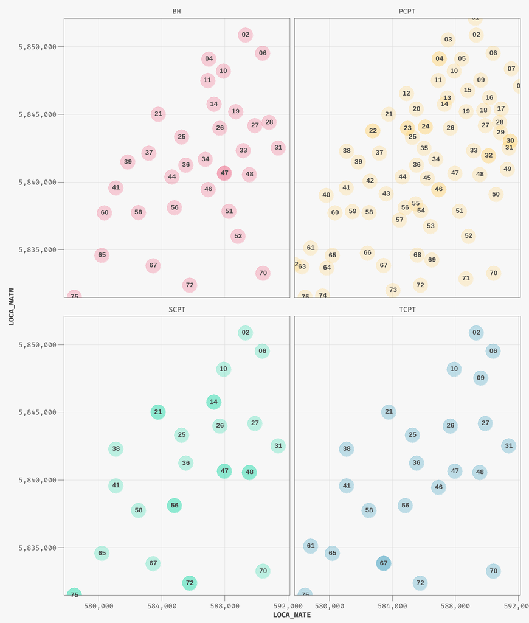

*Plan view of the site.*

```r
ggplot(data_loc, aes(LOCA_NATE, LOCA_NATN)) +
  geom_point(aes(color = TYPE), size = 8, alpha = 1/4) +
  geom_richtext(
    data = data_loc, aes(label = LOCA_NR),
    color = annotation_color,
    family = annotation_family,
    size = annotation_size,
    fill = NA,
    label.color = annotation_label.color,
    label.padding = annotation_label.padding,
    label.r = annotation_label.r,
    hjust = annotation_hjust,
    vjust = annotation_vjust,
    fontface = annotation_fontface
  ) +
  facet_wrap(~TYPE) +
  scale_x_continuous(labels = scales::comma) +
  scale_y_continuous(labels = scales::comma) +
  coord_cartesian(expand = c(0, 0)) +
  scale_color_manual(values = c(col_r, col_y, col_g, col_b)) +
  theme(legend.position = "none")
```

Here we have a lateral view from the EW direction, showing the maximum depth reached from each test `TYPE`.

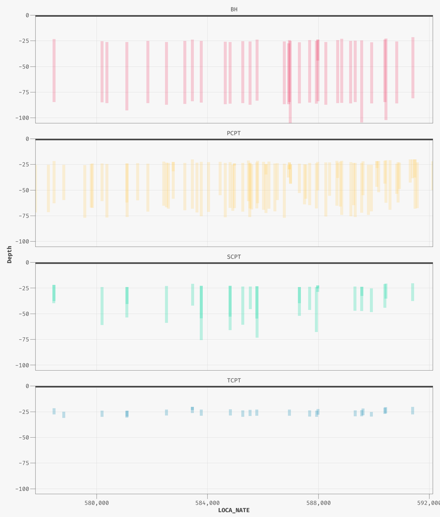

*Section view of the site from EW.*

```r
ggplot(data_loc) +
  geom_segment(aes(x = LOCA_NATE, y = -LOCA_WDEP, xend = LOCA_NATE, yend = -(LOCA_WDEP + LOCA_FDEP),
                   color = TYPE), size = 2, alpha = 1/4) +
  geom_hline(yintercept = 0, color = gray_2, size = 2, alpha = 1) + # sea level
  facet_wrap(~TYPE, ncol = 1) +
  scale_x_continuous(labels = scales::comma) +
  scale_y_continuous(labels = scales::comma) +
  coord_cartesian(expand = c(0, 0)) +
  scale_color_manual(values = c(col_r, col_y, col_g, col_b)) +
  theme(legend.position = "none") +
  labs(y = "Depth")
```

There is basically one `PCTP` test for each location, while the number of `SCPT`s is smaller (normally), as the latest are performed only in a portion of all locations. Down-hole CPTUs, represented by `BH`s, complement the `PCPT` and `SCPT` tests, in depths where seabed CPTUs could not have been completed. `TCPT` tests are much shallower (up to 6m) and relevant to the design of subsea cables. We are not going to consider `TCPT`s in our analysis.

## 3.2 CPTU data

### 3.2.1 Read CPTU data

From the same set of AGS 4.0 files I have extracted the data recorded from the CPTU tests. Let’s read these data and preview the first 100 rows.

```r
data_cpt <-
  vroom("cpt.csv") %>%
  select(-c(SCPT_TEMP, FILE_FSET)) %>% # we don't need these
  mutate(across(is.character, as.factor))
data_cpt
```

```
## # A tibble: 240,550 x 15
##    LOCA_ID    SCPG_TESN SCPT_DPTH SCPT_RES SCPT_FRES SCPT_PWP2 SCPT_FRR SCPT_QT
##    <fct>      <fct>         <dbl>    <dbl>     <dbl>     <dbl>    <dbl>   <dbl>
##  1 HKN01-PCPT 1              0       0.003     NA         NA      NA      0.004
##  2 HKN01-PCPT 1              0.02    0.042     NA         NA      NA      0.042
##  3 HKN01-PCPT 1              0.04    0.08      NA         NA      NA      0.08
##  4 HKN01-PCPT 1              0.06    0.118     NA         NA      NA      0.119
##  5 HKN01-PCPT 1              0.08    0.157      8.35       1.9    32.8    0.157
##  6 HKN01-PCPT 1              0.1     0.354      6.62       1.8     1.97   0.355
##  7 HKN01-PCPT 1              0.12    0.527      7.5        1.9     1.50   0.528
##  8 HKN01-PCPT 1              0.14    0.602      9.32       1.9     1.52   0.603
##  9 HKN01-PCPT 1              0.16    0.705     11.1        1.9     1.54   0.706
## 10 HKN01-PCPT 1              0.18    0.827     13.0        2.1     1.56   0.828
## # ... with 240,540 more rows, and 7 more variables: SCPT_QNET <dbl>,
## #   SCPT_BQ <dbl>, SCPT_CIC1 <dbl>, SCPT_CISB <dbl>, SCPT_NQC1 <dbl>,
## #   SCPT_NRF1 <dbl>, SCPT_CUW1 <dbl>
```

```r
# table
func_tbl(head(data_cpt, 100))
```

| LOCA_ID | SCPG_TESN | SCPT_DPTH | SCPT_RES | SCPT_FRES | SCPT_PWP2 | SCPT_FRR | SCPT_QT | SCPT_QNET | SCPT_BQ | SCPT_CIC1 | SCPT_CISB | SCPT_NQC1 | SCPT_NRF1 | SCPT_CUW1 |
| --- | --- | --- | --- | --- | --- | --- | --- | --- | --- | --- | --- | --- | --- | --- |
| HKN01-PCPT | 1 | 0.00 | 0.003 | NA | NA | NA | 0.004 | 0.004 | 0.2436 | NA | NA | NA | 6.529 | 19.7 |
| HKN01-PCPT | 1 | 0.02 | 0.042 | NA | NA | NA | 0.042 | 0.042 | 0.1835 | 2.56 | 4.93 | 73.8 | 6.017 | 19.7 |
| HKN01-PCPT | 1 | 0.04 | 0.080 | NA | NA | NA | 0.080 | 0.080 | 0.1234 | 2.56 | 4.92 | 78.9 | 6.307 | 19.7 |
| HKN01-PCPT | 1 | 0.06 | 0.118 | NA | NA | NA | 0.119 | 0.117 | 0.0633 | 2.56 | 4.92 | 81.1 | 6.409 | 19.7 |
| HKN01-PCPT | 1 | 0.08 | 0.157 | 8.353 | 1.9 | 32.777 | 0.157 | 0.156 | 0.0034 | 2.51 | 4.27 | 78.8 | 5.364 | 19.7 |
| HKN01-PCPT | 1 | 0.10 | 0.354 | 6.625 | 1.8 | 1.969 | 0.355 | 0.353 | 0.0016 | 2.16 | 3.29 | 81.3 | 1.878 | 19.7 |
| HKN01-PCPT | 1 | 0.12 | 0.527 | 7.500 | 1.9 | 1.495 | 0.528 | 0.526 | 0.0011 | 2.06 | 3.08 | 87.4 | 1.427 | 19.7 |
| HKN01-PCPT | 1 | 0.14 | 0.602 | 9.325 | 1.9 | 1.518 | 0.603 | 0.600 | 0.0011 | 2.06 | 3.03 | 93.4 | 1.554 | 19.7 |
| HKN01-PCPT | 1 | 0.16 | 0.705 | 11.149 | 1.9 | 1.541 | 0.706 | 0.703 | 0.0003 | 2.05 | 2.98 | 98.5 | 1.587 | 19.7 |
| HKN01-PCPT | 1 | 0.18 | 0.827 | 12.973 | 2.1 | 1.565 | 0.828 | 0.824 | 0.0005 | 2.03 | 2.92 | 104.0 | 1.574 | 19.7 |
| HKN01-PCPT | 1 | 0.20 | 0.941 | 14.797 | 2.3 | 1.588 | 0.942 | 0.938 | 0.0003 | 2.02 | 2.87 | 108.6 | 1.577 | 19.7 |
| HKN01-PCPT | 1 | 0.22 | 0.933 | 8.161 | 2.6 | 0.876 | 0.934 | 0.930 | 0.0003 | 1.92 | 2.76 | 87.0 | 0.878 | 19.7 |
| HKN01-PCPT | 1 | 0.24 | 0.988 | 7.077 | 2.9 | 0.761 | 0.989 | 0.984 | 0.0004 | 1.89 | 2.71 | 83.2 | 0.719 | 19.7 |
| HKN01-PCPT | 1 | 0.26 | 1.043 | 9.129 | 3.2 | 0.982 | 1.044 | 1.039 | 0.0005 | 1.91 | 2.73 | 89.1 | 0.879 | 19.7 |
| HKN01-PCPT | 1 | 0.28 | 1.097 | 9.944 | 3.5 | 1.069 | 1.099 | 1.093 | 0.0005 | 1.92 | 2.73 | 90.2 | 0.910 | 19.7 |
| HKN01-PCPT | 1 | 0.30 | 1.152 | 16.997 | 3.8 | 1.828 | 1.154 | 1.148 | 0.0006 | 2.02 | 2.83 | 102.0 | 1.481 | 19.7 |
| HKN01-PCPT | 1 | 0.32 | 1.298 | 23.855 | 4.3 | 1.920 | 1.300 | 1.294 | 0.0008 | 2.05 | 2.79 | 115.3 | 1.844 | 19.7 |
| HKN01-PCPT | 1 | 0.34 | 1.435 | 25.418 | 4.7 | 1.801 | 1.437 | 1.431 | 0.0009 | 2.03 | 2.74 | 119.3 | 1.777 | 19.7 |
| HKN01-PCPT | 1 | 0.36 | 1.356 | 25.986 | 5.1 | 1.857 | 1.358 | 1.351 | 0.0011 | 2.06 | 2.77 | 115.5 | 1.924 | 19.7 |
| HKN01-PCPT | 1 | 0.38 | 1.454 | 25.135 | 4.5 | 1.785 | 1.456 | 1.448 | 0.0005 | 2.03 | 2.74 | 115.2 | 1.735 | 19.7 |
| HKN01-PCPT | 1 | 0.40 | 1.551 | 23.319 | 4.8 | 1.519 | 1.553 | 1.545 | 0.0004 | 1.99 | 2.68 | 112.1 | 1.509 | 19.7 |
| HKN01-PCPT | 1 | 0.42 | 1.413 | 20.760 | 5.2 | 1.447 | 1.415 | 1.407 | 0.0006 | 2.01 | 2.70 | 103.2 | 1.476 | 19.7 |
| HKN01-PCPT | 1 | 0.44 | 1.467 | 19.153 | 5.1 | 1.329 | 1.469 | 1.460 | 0.0004 | 1.99 | 2.67 | 99.5 | 1.312 | 19.7 |
| HKN01-PCPT | 1 | 0.46 | 1.565 | 18.569 | 5.3 | 1.213 | 1.567 | 1.558 | 0.0004 | 1.96 | 2.62 | 99.9 | 1.192 | 19.7 |
| HKN01-PCPT | 1 | 0.48 | 1.615 | 19.665 | 5.6 | 1.230 | 1.617 | 1.608 | 0.0004 | 1.96 | 2.61 | 101.0 | 1.223 | 19.7 |
| HKN01-PCPT | 1 | 0.50 | 1.709 | 21.744 | 5.5 | 1.302 | 1.711 | 1.702 | 0.0003 | 1.96 | 2.60 | 105.7 | 1.278 | 19.7 |
| HKN01-PCPT | 1 | 0.52 | 1.792 | 22.870 | 5.6 | 1.294 | 1.794 | 1.784 | 0.0003 | 1.96 | 2.59 | 107.6 | 1.282 | 19.7 |
| HKN01-PCPT | 1 | 0.54 | 1.867 | 22.894 | 6.2 | 1.242 | 1.869 | 1.859 | 0.0003 | 1.94 | 2.56 | 108.1 | 1.232 | 19.7 |
| HKN01-PCPT | 1 | 0.56 | 1.958 | 20.578 | 6.9 | 1.071 | 1.961 | 1.950 | 0.0005 | 1.91 | 2.51 | 105.1 | 1.056 | 19.7 |
| HKN01-PCPT | 1 | 0.58 | 2.040 | 22.219 | 7.3 | 1.099 | 2.043 | 2.032 | 0.0007 | 1.91 | 2.50 | 108.9 | 1.093 | 19.7 |

[output cut: 70 more lines]

There are ~ 240k available data points here. We have the classic parameters we get from a CPTU test, with the addition of few derived parameters. More specifically:

- `SCPG_TESN`: is the CPTU stroke or push;
- `SCPT_DPTH`: is the depth of result;
- `SCPT_RES`: is the cone resistance `qc`;
- `SCPT_FRES`: is the local unit side friction resistance `fs`;
- `SCPT_PWP2`: is the shoulder porewater pressure `u2`;
- `SCPT_FRR`: is the friction ratio `Rf`;
- `SCPT_QT`: is the corrected cone resistance `qt`;
- `SCPT_QNET`: is the net cone resistance `qn`;
- `SCPT_BQ`: is the pore pressure ratio `Bq`;
- `SCPT_CIC1`: is the soil behaviour type index `Ic`;
- `SCPT_CISB`: is the non-normalized soil behaviour type index `ISBT`;
- `SCPT_NQC1`: is the normalised cone resistance `Qt`;
- `SCPT_NRF1`: is the normalised friction ratio `Fr`;
- `SCPT_CUW1`: is the unit weight.

### 3.2.2 Merge data

We merge the `data_loc` and `data_cpt` data, so everything is in one place and we can connect location to measured CPTU parameters. This makes it easier to explore and understand the data. We are also leaving out `TCPT` measurements.

```r
data_join <- left_join(data_loc, data_cpt, by = "LOCA_ID") %>% filter(TYPE != "TCPT")

# table
func_tbl(head(data_join, 100))
```

| LOCA_ID | LOCA_NATE | LOCA_NATN | LOCA_FDEP | LOCA_WDEP | TYPE | LOCATION | LOCA_NR | SCPG_TESN | SCPT_DPTH | SCPT_RES | SCPT_FRES | SCPT_PWP2 | SCPT_FRR | SCPT_QT | SCPT_QNET | SCPT_BQ | SCPT_CIC1 | SCPT_CISB | SCPT_NQC1 | SCPT_NRF1 | SCPT_CUW1 |
| --- | --- | --- | --- | --- | --- | --- | --- | --- | --- | --- | --- | --- | --- | --- | --- | --- | --- | --- | --- | --- | --- |
| HKN01-PCPT | 589266.1 | 5852097 | 41.03 | 23.7 | PCPT | HKN01 | 01 | 1 | 0.00 | 0.003 | NA | NA | NA | 0.004 | 0.004 | 0.2436 | NA | NA | NA | 6.529 | 19.7 |
| HKN01-PCPT | 589266.1 | 5852097 | 41.03 | 23.7 | PCPT | HKN01 | 01 | 1 | 0.02 | 0.042 | NA | NA | NA | 0.042 | 0.042 | 0.1835 | 2.56 | 4.93 | 73.8 | 6.017 | 19.7 |
| HKN01-PCPT | 589266.1 | 5852097 | 41.03 | 23.7 | PCPT | HKN01 | 01 | 1 | 0.04 | 0.080 | NA | NA | NA | 0.080 | 0.080 | 0.1234 | 2.56 | 4.92 | 78.9 | 6.307 | 19.7 |
| HKN01-PCPT | 589266.1 | 5852097 | 41.03 | 23.7 | PCPT | HKN01 | 01 | 1 | 0.06 | 0.118 | NA | NA | NA | 0.119 | 0.117 | 0.0633 | 2.56 | 4.92 | 81.1 | 6.409 | 19.7 |
| HKN01-PCPT | 589266.1 | 5852097 | 41.03 | 23.7 | PCPT | HKN01 | 01 | 1 | 0.08 | 0.157 | 8.353 | 1.9 | 32.777 | 0.157 | 0.156 | 0.0034 | 2.51 | 4.27 | 78.8 | 5.364 | 19.7 |
| HKN01-PCPT | 589266.1 | 5852097 | 41.03 | 23.7 | PCPT | HKN01 | 01 | 1 | 0.10 | 0.354 | 6.625 | 1.8 | 1.969 | 0.355 | 0.353 | 0.0016 | 2.16 | 3.29 | 81.3 | 1.878 | 19.7 |
| HKN01-PCPT | 589266.1 | 5852097 | 41.03 | 23.7 | PCPT | HKN01 | 01 | 1 | 0.12 | 0.527 | 7.500 | 1.9 | 1.495 | 0.528 | 0.526 | 0.0011 | 2.06 | 3.08 | 87.4 | 1.427 | 19.7 |
| HKN01-PCPT | 589266.1 | 5852097 | 41.03 | 23.7 | PCPT | HKN01 | 01 | 1 | 0.14 | 0.602 | 9.325 | 1.9 | 1.518 | 0.603 | 0.600 | 0.0011 | 2.06 | 3.03 | 93.4 | 1.554 | 19.7 |
| HKN01-PCPT | 589266.1 | 5852097 | 41.03 | 23.7 | PCPT | HKN01 | 01 | 1 | 0.16 | 0.705 | 11.149 | 1.9 | 1.541 | 0.706 | 0.703 | 0.0003 | 2.05 | 2.98 | 98.5 | 1.587 | 19.7 |
| HKN01-PCPT | 589266.1 | 5852097 | 41.03 | 23.7 | PCPT | HKN01 | 01 | 1 | 0.18 | 0.827 | 12.973 | 2.1 | 1.565 | 0.828 | 0.824 | 0.0005 | 2.03 | 2.92 | 104.0 | 1.574 | 19.7 |
| HKN01-PCPT | 589266.1 | 5852097 | 41.03 | 23.7 | PCPT | HKN01 | 01 | 1 | 0.20 | 0.941 | 14.797 | 2.3 | 1.588 | 0.942 | 0.938 | 0.0003 | 2.02 | 2.87 | 108.6 | 1.577 | 19.7 |
| HKN01-PCPT | 589266.1 | 5852097 | 41.03 | 23.7 | PCPT | HKN01 | 01 | 1 | 0.22 | 0.933 | 8.161 | 2.6 | 0.876 | 0.934 | 0.930 | 0.0003 | 1.92 | 2.76 | 87.0 | 0.878 | 19.7 |
| HKN01-PCPT | 589266.1 | 5852097 | 41.03 | 23.7 | PCPT | HKN01 | 01 | 1 | 0.24 | 0.988 | 7.077 | 2.9 | 0.761 | 0.989 | 0.984 | 0.0004 | 1.89 | 2.71 | 83.2 | 0.719 | 19.7 |
| HKN01-PCPT | 589266.1 | 5852097 | 41.03 | 23.7 | PCPT | HKN01 | 01 | 1 | 0.26 | 1.043 | 9.129 | 3.2 | 0.982 | 1.044 | 1.039 | 0.0005 | 1.91 | 2.73 | 89.1 | 0.879 | 19.7 |
| HKN01-PCPT | 589266.1 | 5852097 | 41.03 | 23.7 | PCPT | HKN01 | 01 | 1 | 0.28 | 1.097 | 9.944 | 3.5 | 1.069 | 1.099 | 1.093 | 0.0005 | 1.92 | 2.73 | 90.2 | 0.910 | 19.7 |
| HKN01-PCPT | 589266.1 | 5852097 | 41.03 | 23.7 | PCPT | HKN01 | 01 | 1 | 0.30 | 1.152 | 16.997 | 3.8 | 1.828 | 1.154 | 1.148 | 0.0006 | 2.02 | 2.83 | 102.0 | 1.481 | 19.7 |
| HKN01-PCPT | 589266.1 | 5852097 | 41.03 | 23.7 | PCPT | HKN01 | 01 | 1 | 0.32 | 1.298 | 23.855 | 4.3 | 1.920 | 1.300 | 1.294 | 0.0008 | 2.05 | 2.79 | 115.3 | 1.844 | 19.7 |
| HKN01-PCPT | 589266.1 | 5852097 | 41.03 | 23.7 | PCPT | HKN01 | 01 | 1 | 0.34 | 1.435 | 25.418 | 4.7 | 1.801 | 1.437 | 1.431 | 0.0009 | 2.03 | 2.74 | 119.3 | 1.777 | 19.7 |
| HKN01-PCPT | 589266.1 | 5852097 | 41.03 | 23.7 | PCPT | HKN01 | 01 | 1 | 0.36 | 1.356 | 25.986 | 5.1 | 1.857 | 1.358 | 1.351 | 0.0011 | 2.06 | 2.77 | 115.5 | 1.924 | 19.7 |
| HKN01-PCPT | 589266.1 | 5852097 | 41.03 | 23.7 | PCPT | HKN01 | 01 | 1 | 0.38 | 1.454 | 25.135 | 4.5 | 1.785 | 1.456 | 1.448 | 0.0005 | 2.03 | 2.74 | 115.2 | 1.735 | 19.7 |
| HKN01-PCPT | 589266.1 | 5852097 | 41.03 | 23.7 | PCPT | HKN01 | 01 | 1 | 0.40 | 1.551 | 23.319 | 4.8 | 1.519 | 1.553 | 1.545 | 0.0004 | 1.99 | 2.68 | 112.1 | 1.509 | 19.7 |
| HKN01-PCPT | 589266.1 | 5852097 | 41.03 | 23.7 | PCPT | HKN01 | 01 | 1 | 0.42 | 1.413 | 20.760 | 5.2 | 1.447 | 1.415 | 1.407 | 0.0006 | 2.01 | 2.70 | 103.2 | 1.476 | 19.7 |
| HKN01-PCPT | 589266.1 | 5852097 | 41.03 | 23.7 | PCPT | HKN01 | 01 | 1 | 0.44 | 1.467 | 19.153 | 5.1 | 1.329 | 1.469 | 1.460 | 0.0004 | 1.99 | 2.67 | 99.5 | 1.312 | 19.7 |
| HKN01-PCPT | 589266.1 | 5852097 | 41.03 | 23.7 | PCPT | HKN01 | 01 | 1 | 0.46 | 1.565 | 18.569 | 5.3 | 1.213 | 1.567 | 1.558 | 0.0004 | 1.96 | 2.62 | 99.9 | 1.192 | 19.7 |
| HKN01-PCPT | 589266.1 | 5852097 | 41.03 | 23.7 | PCPT | HKN01 | 01 | 1 | 0.48 | 1.615 | 19.665 | 5.6 | 1.230 | 1.617 | 1.608 | 0.0004 | 1.96 | 2.61 | 101.0 | 1.223 | 19.7 |
| HKN01-PCPT | 589266.1 | 5852097 | 41.03 | 23.7 | PCPT | HKN01 | 01 | 1 | 0.50 | 1.709 | 21.744 | 5.5 | 1.302 | 1.711 | 1.702 | 0.0003 | 1.96 | 2.60 | 105.7 | 1.278 | 19.7 |
| HKN01-PCPT | 589266.1 | 5852097 | 41.03 | 23.7 | PCPT | HKN01 | 01 | 1 | 0.52 | 1.792 | 22.870 | 5.6 | 1.294 | 1.794 | 1.784 | 0.0003 | 1.96 | 2.59 | 107.6 | 1.282 | 19.7 |
| HKN01-PCPT | 589266.1 | 5852097 | 41.03 | 23.7 | PCPT | HKN01 | 01 | 1 | 0.54 | 1.867 | 22.894 | 6.2 | 1.242 | 1.869 | 1.859 | 0.0003 | 1.94 | 2.56 | 108.1 | 1.232 | 19.7 |
| HKN01-PCPT | 589266.1 | 5852097 | 41.03 | 23.7 | PCPT | HKN01 | 01 | 1 | 0.56 | 1.958 | 20.578 | 6.9 | 1.071 | 1.961 | 1.950 | 0.0005 | 1.91 | 2.51 | 105.1 | 1.056 | 19.7 |
| HKN01-PCPT | 589266.1 | 5852097 | 41.03 | 23.7 | PCPT | HKN01 | 01 | 1 | 0.58 | 2.040 | 22.219 | 7.3 | 1.099 | 2.043 | 2.032 | 0.0007 | 1.91 | 2.50 | 108.9 | 1.093 | 19.7 |

[output cut: 70 more lines]

That’s it! Thanks for reading 👋